# Hierarchical clustering

### Problem Statement:-

- Perform Clustering for the crime data and identify the number of clusters formed and draw inferences.

### Data Understanding and Preparation

```r
#Reading the dataset
crime <- read.csv("~/desktop/Digi 360/Module 12/crime_data.csv")
```

```r
head(crime)
```

|  | X | Murder | Assault | UrbanPop | Rape |
| --- | --- | --- | --- | --- | --- |
| 1 | Alabama | 13.2 | 236 | 58 | 21.2 |
| 2 | Alaska | 10.0 | 263 | 48 | 44.5 |
| 3 | Arizona | 8.1 | 294 | 80 | 31.0 |
| 4 | Arkansas | 8.8 | 190 | 50 | 19.5 |
| 5 | California | 9.0 | 276 | 91 | 40.6 |
| 6 | Colorado | 7.9 | 204 | 78 | 38.7 |

```r
any(is.na(crime))
```

```
[1] FALSE
```

```r
#Removing First column since it is categorical
crime_num <- crime[, -c(1)]
head(crime_num)
```

|  | Murder | Assault | UrbanPop | Rape |
| --- | --- | --- | --- | --- |
| 1 | 13.2 | 236 | 58 | 21.2 |
| 2 | 10.0 | 263 | 48 | 44.5 |
| 3 | 8.1 | 294 | 80 | 31.0 |
| 4 | 8.8 | 190 | 50 | 19.5 |
| 5 | 9.0 | 276 | 91 | 40.6 |
| 6 | 7.9 | 204 | 78 | 38.7 |

```r
summary(crime_num)
```

```
     Murder          Assault         UrbanPop          Rape
 Min.   : 0.800   Min.   : 45.0   Min.   :32.00   Min.   : 7.30
 1st Qu.: 4.075   1st Qu.:109.0   1st Qu.:54.50   1st Qu.:15.07
 Median : 7.250   Median :159.0   Median :66.00   Median :20.10
 Mean   : 7.788   Mean   :170.8   Mean   :65.54   Mean   :21.23
 3rd Qu.:11.250   3rd Qu.:249.0   3rd Qu.:77.75   3rd Qu.:26.18
 Max.   :17.400   Max.   :337.0   Max.   :91.00   Max.   :46.00
```

### Scaling

Before applying Hierarchical Clustering, we have to normalize the data so that the scale of each variable is the same. Why is this important? Well, if the scale of the variables is not the same, the model might become biased towards the variables with a higher magnitude.

```r
crime_scaled <- as.data.frame(scale(crime_num))
summary(crime_scaled)
```

```
     Murder           Assault           UrbanPop             Rape
 Min.   :-1.6044   Min.   :-1.5090   Min.   :-2.31714   Min.   :-1.4874
 1st Qu.:-0.8525   1st Qu.:-0.7411   1st Qu.:-0.76271   1st Qu.:-0.6574
 Median :-0.1235   Median :-0.1411   Median : 0.03178   Median :-0.1209
 Mean   : 0.0000   Mean   : 0.0000   Mean   : 0.00000   Mean   : 0.0000
 3rd Qu.: 0.7949   3rd Qu.: 0.9388   3rd Qu.: 0.84354   3rd Qu.: 0.5277
 Max.   : 2.2069   Max.   : 1.9948   Max.   : 1.75892   Max.   : 2.6444
```

Since all the values here are continuous numerical values, you will use the euclidean distance method.

### Building the Model

```r
dist_mat <- dist(crime_scaled, method = 'euclidean')
hclust_ward <- hclust(dist_mat, method = 'ward.D2')
```

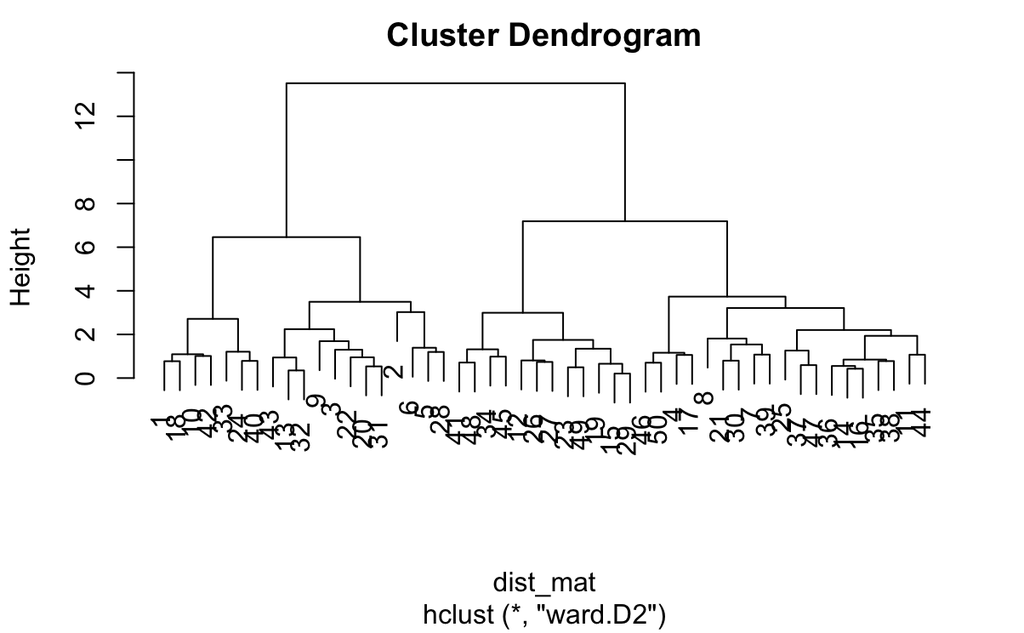

```r
#Plotting the dendrogram
plot(hclust_ward)
```

### Cutting the Dendrogram

```r
cut_ward <- cutree(hclust_ward, k = 4)
```

```r
plot(hclust_ward)
rect.hclust(hclust_ward , k = 4, border = 2:6)
```

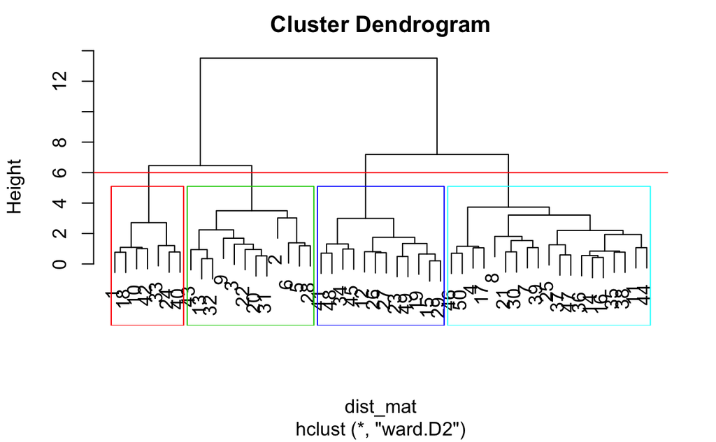

```r
abline(h = 6, col = 'red')
```

Let’s visualize the tree with different colored branches using package `dendextend`

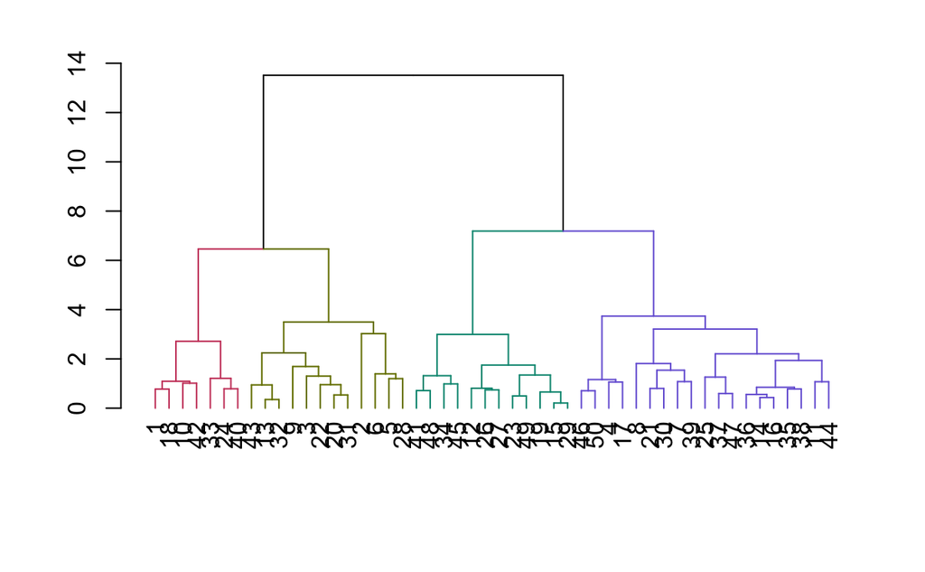

```r
suppressPackageStartupMessages(library(dendextend))
ward_dend_obj <- as.dendrogram(hclust_ward)
ward_col_dend <- color_branches(ward_dend_obj, h = 6)
plot(ward_col_dend)
```

```r
#Appending the clusters to original dataframe.
suppressPackageStartupMessages(library(dplyr))
crime_cl <- mutate(crime, cluster = cut_ward)
```

```r
head(crime_cl)
```

|  | X | Murder | Assault | UrbanPop | Rape | cluster |
| --- | --- | --- | --- | --- | --- | --- |
| 1 | Alabama | 13.2 | 236 | 58 | 21.2 | 1 |
| 2 | Alaska | 10.0 | 263 | 48 | 44.5 | 2 |
| 3 | Arizona | 8.1 | 294 | 80 | 31.0 | 2 |
| 4 | Arkansas | 8.8 | 190 | 50 | 19.5 | 3 |
| 5 | California | 9.0 | 276 | 91 | 40.6 | 2 |
| 6 | Colorado | 7.9 | 204 | 78 | 38.7 | 2 |

```r
#Rename column X as "State"
colnames(crime_cl) <- c("State", "Murder","Assault", "Urbanpop", "Rape", "Cluster")
head(crime_cl)
```

|  | State | Murder | Assault | Urbanpop | Rape | Cluster |
| --- | --- | --- | --- | --- | --- | --- |
| 1 | Alabama | 13.2 | 236 | 58 | 21.2 | 1 |
| 2 | Alaska | 10.0 | 263 | 48 | 44.5 | 2 |
| 3 | Arizona | 8.1 | 294 | 80 | 31.0 | 2 |
| 4 | Arkansas | 8.8 | 190 | 50 | 19.5 | 3 |
| 5 | California | 9.0 | 276 | 91 | 40.6 | 2 |
| 6 | Colorado | 7.9 | 204 | 78 | 38.7 | 2 |

### Visualizing few attributes

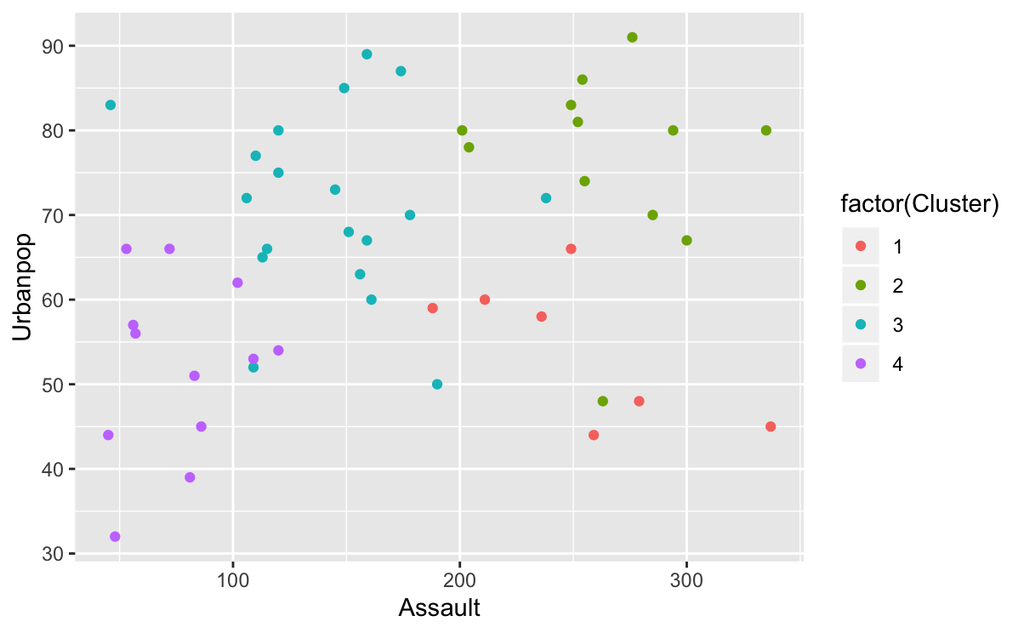

```r
suppressPackageStartupMessages(library(ggplot2))
ggplot(crime_cl, aes(x=Assault, y = Urbanpop, color = factor(Cluster))) + geom_point()
```

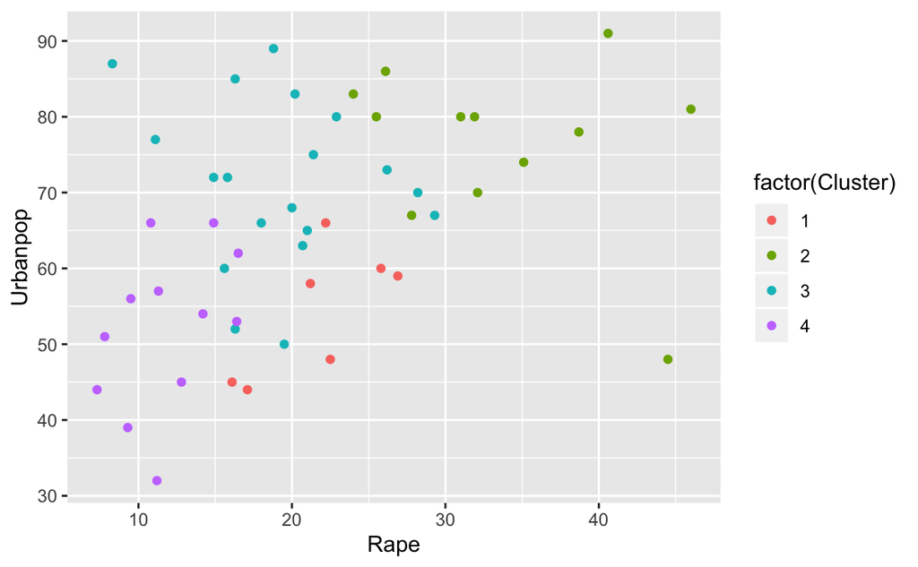

```r
suppressPackageStartupMessages(library(ggplot2))
ggplot(crime_cl, aes(x=Rape, y = Urbanpop, color = factor(Cluster))) + geom_point()
```

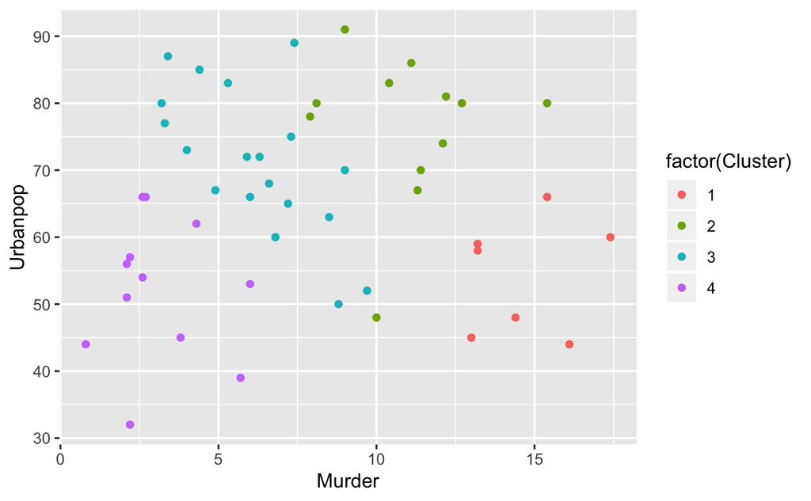

```r
suppressPackageStartupMessages(library(ggplot2))
ggplot(crime_cl, aes(x=Murder, y = Urbanpop, color = factor(Cluster))) + geom_point()
```

```r
#Writing the final file with assigned cluster IDs.
write.csv(crime_cl, file="~/desktop/Digi 360/Module 12/crime_final_R.csv")
```

### Conclusion

- Chosen the threshold as 6 to cut the dendrogram considering above this threshold is maximum distance.
- The cut-off line is intersecting at four points in dendrogram, so 4 clusters have been chosen.